# Risk Factor Analysis

## Outcome Variable

**Outcome Variable:** whz

## Predictor Variables

**Intervention Variable:** hhwealth_quart

**Adjustment Set:**

unadjusted

## Stratifying Variables

The analysis was stratified on these variable(s):

- agecat
- studyid
- country

## Data Summary

| agecat | studyid | country | hhwealth_quart | n_cell | n |
| --- | --- | --- | --- | --- | --- |
| Birth | COHORTS | GUATEMALA | Wealth Q4 | 258 | 729 |
| Birth | COHORTS | GUATEMALA | Wealth Q1 | 144 | 729 |
| Birth | COHORTS | GUATEMALA | Wealth Q2 | 141 | 729 |
| Birth | COHORTS | GUATEMALA | Wealth Q3 | 186 | 729 |
| Birth | COHORTS | PHILIPPINES | Wealth Q4 | 815 | 2898 |
| Birth | COHORTS | PHILIPPINES | Wealth Q1 | 647 | 2898 |
| Birth | COHORTS | PHILIPPINES | Wealth Q2 | 506 | 2898 |
| Birth | COHORTS | PHILIPPINES | Wealth Q3 | 930 | 2898 |
| 6 months | COHORTS | GUATEMALA | Wealth Q4 | 339 | 926 |
| 6 months | COHORTS | GUATEMALA | Wealth Q1 | 176 | 926 |
| 6 months | COHORTS | GUATEMALA | Wealth Q2 | 194 | 926 |
| 6 months | COHORTS | GUATEMALA | Wealth Q3 | 217 | 926 |
| 6 months | COHORTS | PHILIPPINES | Wealth Q4 | 744 | 2706 |
| 6 months | COHORTS | PHILIPPINES | Wealth Q1 | 569 | 2706 |
| 6 months | COHORTS | PHILIPPINES | Wealth Q2 | 485 | 2706 |
| 6 months | COHORTS | PHILIPPINES | Wealth Q3 | 908 | 2706 |
| 24 months | COHORTS | GUATEMALA | Wealth Q4 | 405 | 1046 |
| 24 months | COHORTS | GUATEMALA | Wealth Q1 | 203 | 1046 |
| 24 months | COHORTS | GUATEMALA | Wealth Q2 | 215 | 1046 |
| 24 months | COHORTS | GUATEMALA | Wealth Q3 | 223 | 1046 |
| 24 months | COHORTS | PHILIPPINES | Wealth Q4 | 685 | 2449 |
| 24 months | COHORTS | PHILIPPINES | Wealth Q1 | 492 | 2449 |
| 24 months | COHORTS | PHILIPPINES | Wealth Q2 | 424 | 2449 |
| 24 months | COHORTS | PHILIPPINES | Wealth Q3 | 848 | 2449 |

The following strata were considered:

- agecat: 24 months, studyid: COHORTS, country: GUATEMALA
- agecat: 24 months, studyid: COHORTS, country: PHILIPPINES
- agecat: 6 months, studyid: COHORTS, country: GUATEMALA
- agecat: 6 months, studyid: COHORTS, country: PHILIPPINES
- agecat: Birth, studyid: COHORTS, country: GUATEMALA
- agecat: Birth, studyid: COHORTS, country: PHILIPPINES

## Methods Detail

We’re interested in the causal parameters $E[Y_a]$ for all values of $a \in \mathcal{A}$. These parameters represent the mean outcome if, possibly contrary to fact, we intervened to set all units to have $A=a$. Under the randomization and positivity assumptions, these are identified by the statistical parameters $\psi_a=E_W[E_{Y|A,W}(Y|A=a,W)]$. In addition, we’re interested in the mean of $Y$, $E[Y]$ under no intervention (the observed mean). We will estimate these parameters by using SuperLearner to fit the relevant likelihood factors – $E_{Y|A,W}(Y|A=a,W)$ and $p(A=a|W)$, and then updating our likelihood fit using a joint TMLE.

For unadjusted analyses ($W=\{\}$), initial likelihoods were estimated using Lrnr_glm to estimate the simple $E(Y|A)$ and Lrnr_mean to estimate $p(A)$. For adjusted analyses, a small library containing Lrnr_glmnet, Lrnr_xgboost, and Lrnr_mean was used.

Having estimated these parameters, we will then use the delta method to estimate relative risks and attributable risks relative to a prespecified baseline level of $A$.

# Results Detail

## Results Plots

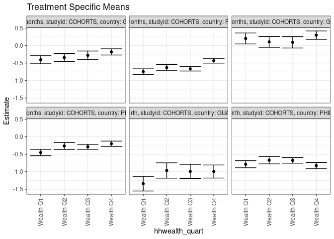

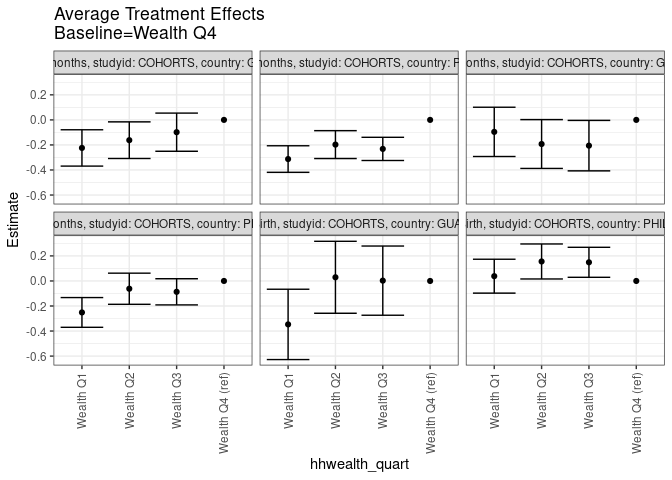

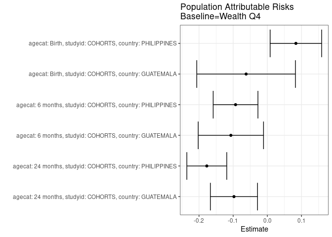

## Results Table

### Parameter: TSM

| agecat | studyid | country | intervention_level | baseline_level | estimate | ci_lower | ci_upper |
| --- | --- | --- | --- | --- | --- | --- | --- |
| Birth | COHORTS | GUATEMALA | Wealth Q4 | NA | -0.9951550 | -1.1817400 | -0.8085701 |
| Birth | COHORTS | GUATEMALA | Wealth Q1 | NA | -1.3420139 | -1.5518154 | -1.1322123 |
| Birth | COHORTS | GUATEMALA | Wealth Q2 | NA | -0.9657447 | -1.1843212 | -0.7471682 |
| Birth | COHORTS | GUATEMALA | Wealth Q3 | NA | -0.9924194 | -1.1962585 | -0.7885802 |
| Birth | COHORTS | PHILIPPINES | Wealth Q4 | NA | -0.8258405 | -0.9156996 | -0.7359814 |
| Birth | COHORTS | PHILIPPINES | Wealth Q1 | NA | -0.7875889 | -0.8888141 | -0.6863637 |
| Birth | COHORTS | PHILIPPINES | Wealth Q2 | NA | -0.6700791 | -0.7769933 | -0.5631648 |
| Birth | COHORTS | PHILIPPINES | Wealth Q3 | NA | -0.6768495 | -0.7560494 | -0.5976495 |
| 6 months | COHORTS | GUATEMALA | Wealth Q4 | NA | 0.2982006 | 0.1788339 | 0.4175672 |
| 6 months | COHORTS | GUATEMALA | Wealth Q1 | NA | 0.2025568 | 0.0459515 | 0.3591621 |
| 6 months | COHORTS | GUATEMALA | Wealth Q2 | NA | 0.1054639 | -0.0488410 | 0.2597688 |
| 6 months | COHORTS | GUATEMALA | Wealth Q3 | NA | 0.0925346 | -0.0698014 | 0.2548706 |
| 6 months | COHORTS | PHILIPPINES | Wealth Q4 | NA | -0.2008065 | -0.2765391 | -0.1250738 |
| 6 months | COHORTS | PHILIPPINES | Wealth Q1 | NA | -0.4521090 | -0.5436444 | -0.3605736 |
| 6 months | COHORTS | PHILIPPINES | Wealth Q2 | NA | -0.2628247 | -0.3615385 | -0.1641110 |
| 6 months | COHORTS | PHILIPPINES | Wealth Q3 | NA | -0.2874670 | -0.3594074 | -0.2155265 |
| 24 months | COHORTS | GUATEMALA | Wealth Q4 | NA | -0.1814321 | -0.2702931 | -0.0925711 |
| 24 months | COHORTS | GUATEMALA | Wealth Q1 | NA | -0.4054187 | -0.5202913 | -0.2905461 |
| 24 months | COHORTS | GUATEMALA | Wealth Q2 | NA | -0.3434419 | -0.4595740 | -0.2273097 |
| 24 months | COHORTS | GUATEMALA | Wealth Q3 | NA | -0.2796413 | -0.4034828 | -0.1557997 |
| 24 months | COHORTS | PHILIPPINES | Wealth Q4 | NA | -0.4327445 | -0.5010904 | -0.3643987 |
| 24 months | COHORTS | PHILIPPINES | Wealth Q1 | NA | -0.7455285 | -0.8266882 | -0.6643687 |
| 24 months | COHORTS | PHILIPPINES | Wealth Q2 | NA | -0.6300708 | -0.7178878 | -0.5422537 |
| 24 months | COHORTS | PHILIPPINES | Wealth Q3 | NA | -0.6643986 | -0.7270155 | -0.6017816 |

### Parameter: E(Y)

| agecat | studyid | country | intervention_level | baseline_level | estimate | ci_lower | ci_upper |
| --- | --- | --- | --- | --- | --- | --- | --- |
| Birth | COHORTS | GUATEMALA | NA | NA | -1.0572840 | -1.1606089 | -0.9539590 |
| Birth | COHORTS | PHILIPPINES | NA | NA | -0.7422912 | -0.7886598 | -0.6959226 |
| 6 months | COHORTS | GUATEMALA | NA | NA | 0.1914471 | 0.1185005 | 0.2643936 |
| 6 months | COHORTS | PHILIPPINES | NA | NA | -0.2938433 | -0.3352064 | -0.2524802 |
| 24 months | COHORTS | GUATEMALA | NA | NA | -0.2791396 | -0.3336899 | -0.2245893 |
| 24 months | COHORTS | PHILIPPINES | NA | NA | -0.6099592 | -0.6467541 | -0.5731643 |

### Parameter: ATE

| agecat | studyid | country | intervention_level | baseline_level | estimate | ci_lower | ci_upper |
| --- | --- | --- | --- | --- | --- | --- | --- |
| Birth | COHORTS | GUATEMALA | Wealth Q4 | Wealth Q4 | 0.0000000 | 0.0000000 | 0.0000000 |
| Birth | COHORTS | GUATEMALA | Wealth Q1 | Wealth Q4 | -0.3468589 | -0.6276268 | -0.0660909 |
| Birth | COHORTS | GUATEMALA | Wealth Q2 | Wealth Q4 | 0.0294104 | -0.2579738 | 0.3167945 |
| Birth | COHORTS | GUATEMALA | Wealth Q3 | Wealth Q4 | 0.0027357 | -0.2736053 | 0.2790767 |
| Birth | COHORTS | PHILIPPINES | Wealth Q4 | Wealth Q4 | 0.0000000 | 0.0000000 | 0.0000000 |
| Birth | COHORTS | PHILIPPINES | Wealth Q1 | Wealth Q4 | 0.0382516 | -0.0971042 | 0.1736075 |
| Birth | COHORTS | PHILIPPINES | Wealth Q2 | Wealth Q4 | 0.1557614 | 0.0161000 | 0.2954229 |
| Birth | COHORTS | PHILIPPINES | Wealth Q3 | Wealth Q4 | 0.1489910 | 0.0292109 | 0.2687712 |
| 6 months | COHORTS | GUATEMALA | Wealth Q4 | Wealth Q4 | 0.0000000 | 0.0000000 | 0.0000000 |
| 6 months | COHORTS | GUATEMALA | Wealth Q1 | Wealth Q4 | -0.0956438 | -0.2925540 | 0.1012664 |
| 6 months | COHORTS | GUATEMALA | Wealth Q2 | Wealth Q4 | -0.1927367 | -0.3878223 | 0.0023489 |
| 6 months | COHORTS | GUATEMALA | Wealth Q3 | Wealth Q4 | -0.2056660 | -0.4071639 | -0.0041682 |
| 6 months | COHORTS | PHILIPPINES | Wealth Q4 | Wealth Q4 | 0.0000000 | 0.0000000 | 0.0000000 |
| 6 months | COHORTS | PHILIPPINES | Wealth Q1 | Wealth Q4 | -0.2513025 | -0.3701056 | -0.1324994 |
| 6 months | COHORTS | PHILIPPINES | Wealth Q2 | Wealth Q4 | -0.0620183 | -0.1864363 | 0.0623998 |
| 6 months | COHORTS | PHILIPPINES | Wealth Q3 | Wealth Q4 | -0.0866605 | -0.1911156 | 0.0177946 |
| 24 months | COHORTS | GUATEMALA | Wealth Q4 | Wealth Q4 | 0.0000000 | 0.0000000 | 0.0000000 |
| 24 months | COHORTS | GUATEMALA | Wealth Q1 | Wealth Q4 | -0.2239866 | -0.3692174 | -0.0787558 |
| 24 months | COHORTS | GUATEMALA | Wealth Q2 | Wealth Q4 | -0.1620098 | -0.3082389 | -0.0157806 |
| 24 months | COHORTS | GUATEMALA | Wealth Q3 | Wealth Q4 | -0.0982092 | -0.2506329 | 0.0542146 |
| 24 months | COHORTS | PHILIPPINES | Wealth Q4 | Wealth Q4 | 0.0000000 | 0.0000000 | 0.0000000 |
| 24 months | COHORTS | PHILIPPINES | Wealth Q1 | Wealth Q4 | -0.3127839 | -0.4188879 | -0.2066799 |
| 24 months | COHORTS | PHILIPPINES | Wealth Q2 | Wealth Q4 | -0.1973262 | -0.3086051 | -0.0860473 |
| 24 months | COHORTS | PHILIPPINES | Wealth Q3 | Wealth Q4 | -0.2316541 | -0.3243473 | -0.1389608 |

### Parameter: PAR

| agecat | studyid | country | intervention_level | baseline_level | estimate | ci_lower | ci_upper |
| --- | --- | --- | --- | --- | --- | --- | --- |
| Birth | COHORTS | GUATEMALA | Wealth Q4 | NA | -0.0621289 | -0.2065173 | 0.0822595 |
| Birth | COHORTS | PHILIPPINES | Wealth Q4 | NA | 0.0835493 | 0.0081632 | 0.1589353 |
| 6 months | COHORTS | GUATEMALA | Wealth Q4 | NA | -0.1067535 | -0.2023421 | -0.0111649 |
| 6 months | COHORTS | PHILIPPINES | Wealth Q4 | NA | -0.0930369 | -0.1585540 | -0.0275197 |
| 24 months | COHORTS | GUATEMALA | Wealth Q4 | NA | -0.0977075 | -0.1666807 | -0.0287343 |
| 24 months | COHORTS | PHILIPPINES | Wealth Q4 | NA | -0.1772146 | -0.2356263 | -0.1188030 |